# IODS course project

Dongming Zhang

# Introduction to Open Data Science - Course Project

# About the project

```r
# This is a so-called "R chunk" where you can write R code.

date()
```

```
## [1] "Mon Nov 22 08:35:11 2021"
```

## My view

### Myself

My name is **Dongming Zhang**, I am a doctoral student at University of Helsinki. My project is working on the genetic study of fungi, such as *Aspergillus niger*, *Trichoderma reesei*.

### Study goals

To be honest, I have the experiences about R, Python, Matlab. But I am not a professional statistics student, my programming ability is limited within how to run the scripts, writing some simple functions Many of programming questions or underlined problems that I did not understand clearly. My supervisor – from department of Microbiology– introduced this amazing course for me. Thus, I would like to study the detailed knowledge about R in this course. In my project, I can proficiently use R to analyze my bioinformatic data.

### My Github (Click the link)

[link](https://github.com/DongmingZhang706/IODS-project.git)

# Regression and model validation (week 2)

- Describe your work and results clearly.
- Assume the reader has an introductory course level understanding of writing and reading R code as well as statistical methods.
- Assume the reader has no previous knowledge of your data or the more advanced methods you are using.

```r
date()
```

```
## [1] "Mon Nov 22 08:35:12 2021"
```

## Read data

```r
students2014 <- read.table("./data/learning2014.txt", sep=",", header=TRUE, stringsAsFactors = T)

str(students2014)
```

```
## 'data.frame':    166 obs. of  7 variables:
##  $ gender  : Factor w/ 2 levels "F","M": 1 2 1 2 2 1 2 1 2 1 ...
##  $ age     : int  53 55 49 53 49 38 50 37 37 42 ...
##  $ attitude: num  3.7 3.1 2.5 3.5 3.7 3.8 3.5 2.9 3.8 2.1 ...
##  $ deep    : num  3.58 2.92 3.5 3.5 3.67 ...
##  $ stra    : num  3.38 2.75 3.62 3.12 3.62 ...
##  $ surf    : num  2.58 3.17 2.25 2.25 2.83 ...
##  $ points  : int  25 12 24 10 22 21 21 31 24 26 ...
```

```r
dim(students2014)
```

```
## [1] 166   7
```

This data is a survey result on teaching and learning. Data was collected on 2014, including the infromation of participants, such as ‘gender’, ‘age’, ‘attitude’. In dataset, ‘deep’ is the mean points of students to answer the 12 deep questions, ‘stra’ is the mean points of students to answer the 12 strategic questions, ‘suf’ is the mean points of students to answer the 12 surface questions. ‘points’ are the exam grades of students. This data frame has 166 observations and 7 variables.

## A graphical overview

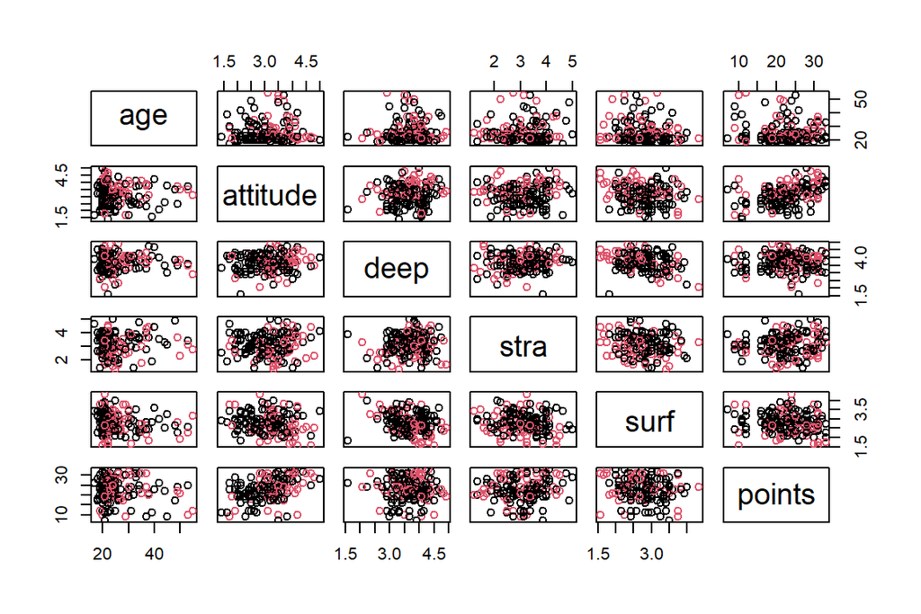

```r
library(ggplot2)
library(GGally)
pairs(students2014[2:7], col = students2014$gender)
```

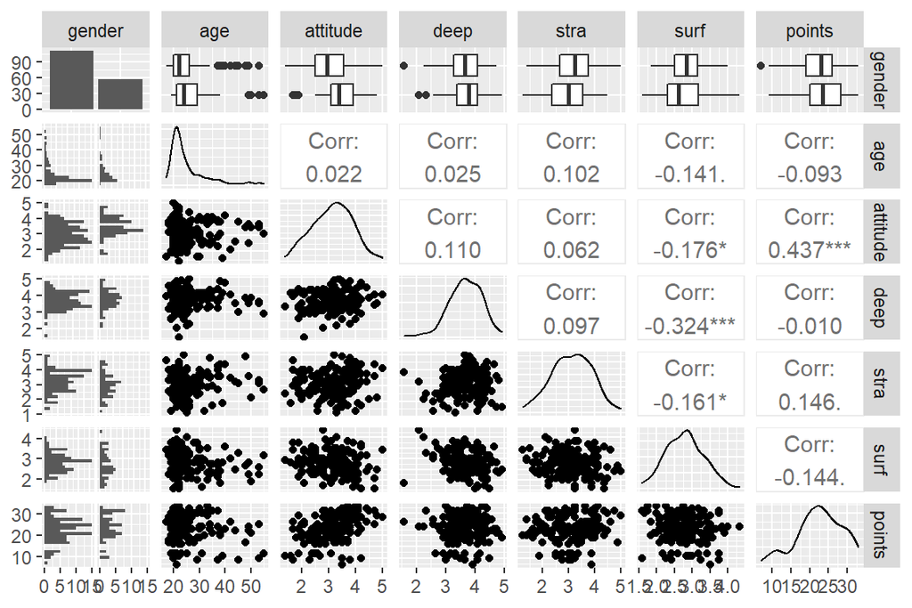

```r
ggpairs(students2014,  lower = list(combo = wrap("facethist", bins = 20)))
```

The above two figures show the relationships among 7 variables. From the ggpairs plot, it is clear that the significant correlations are tagged with asterisks ’*‘. All varibles are normally distributed, excepet the ’age’, the most people attending to survey are aged between 20 and 30. For ‘surf’ results, ‘attitude’, ‘deep’ and ‘stra’ have a significant correlations. the absolute value of ‘deep’ reaches to 0.324, which has the most significant influence to ‘surf’. With regarding to ‘points’, ‘attitude’ has the highest absolute value, 0.437, and the most significant correlationships with ‘points’.